# Trp53cor1 KO vs WT (liver)

[output not shown]

This file shows the wt-v-ko comparison for Trp53cor1.

Cuff overview:

```
## CuffSet instance with:
##   2 samples
##   26754 genes
##   77524 isoforms
##   0 TSS
##   23066 CDS
##   0 promoters
##   0 splicing
##   19954 relCDS
```

# QC

## Dispersion

Dispersion plot for genes in cuff: (Overdispersion can lead to innacurate quants)

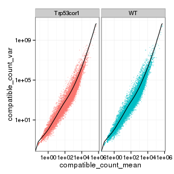

## Cross-replicate variability (fpkmSCVplot)

Differences in CV 2 can result in lower numbers of differentially expressed genes due to a higher degree of variability between replicate fpkm estimates.

Genes:

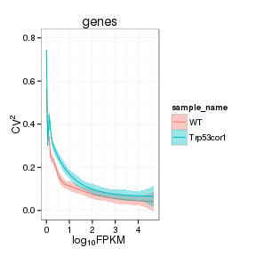

Isoforms:

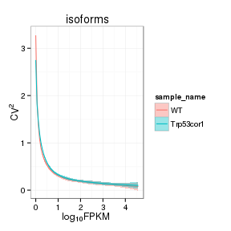

## MvA plot

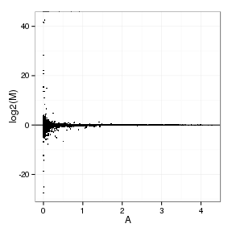

### MvA plot counts

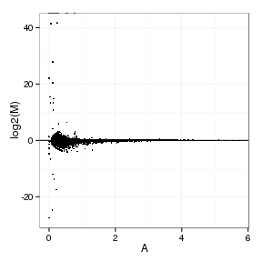

## Scatterplot matrix

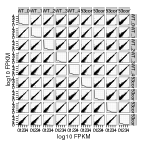

## Distributions

### Boxplots

Boxplot (genes)

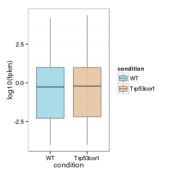

Boxplot (genes, replicates)

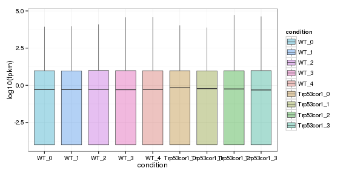

Boxplot (isoforms)

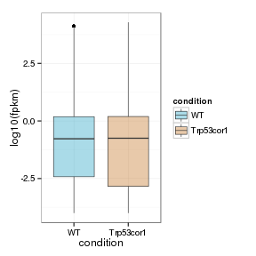

Boxplot (isoforms, replicates)

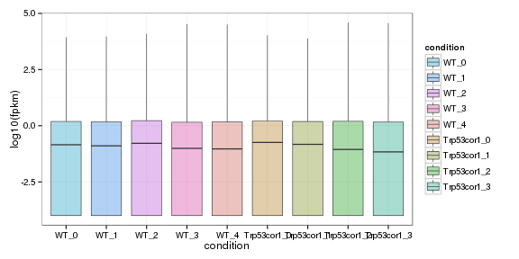

### Density

Density (genes)

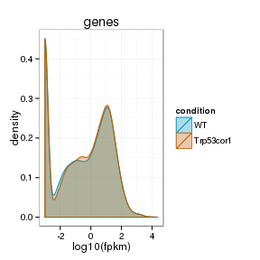

Density (genes, replicates)

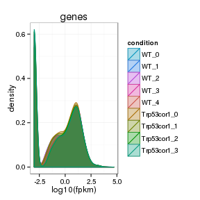

## Clustering

### Replicate Clusters

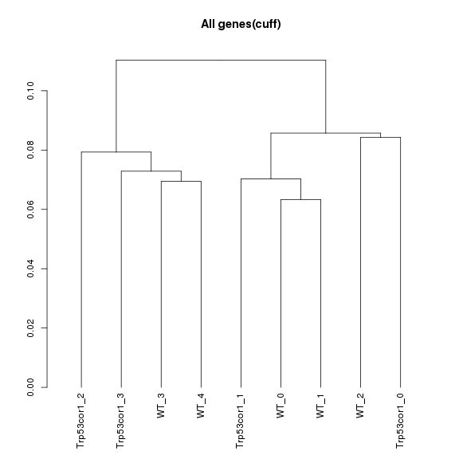

### PCA (genes)

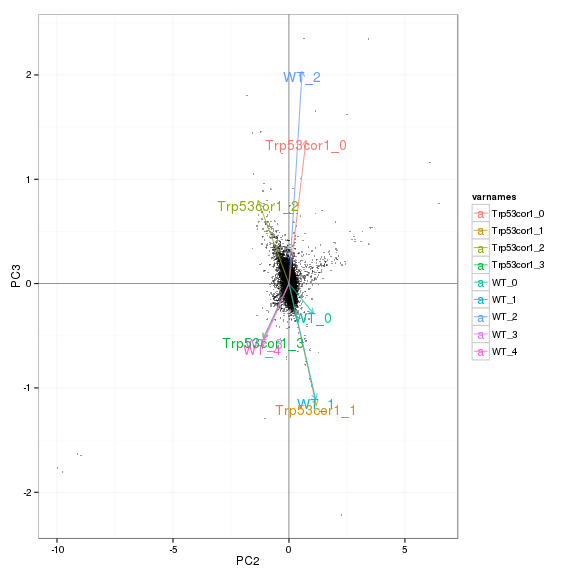

### MDS (genes)

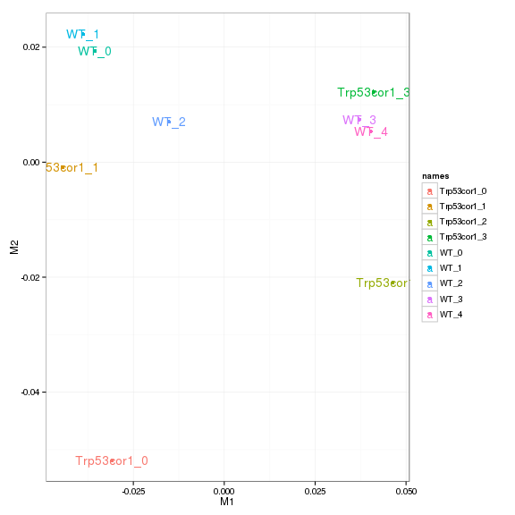

# KO assessment

## Endogenous lncRNA expression

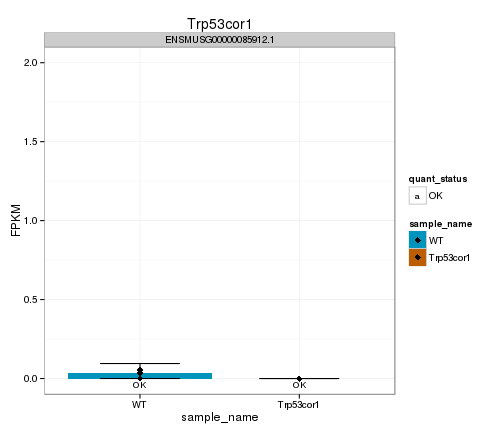

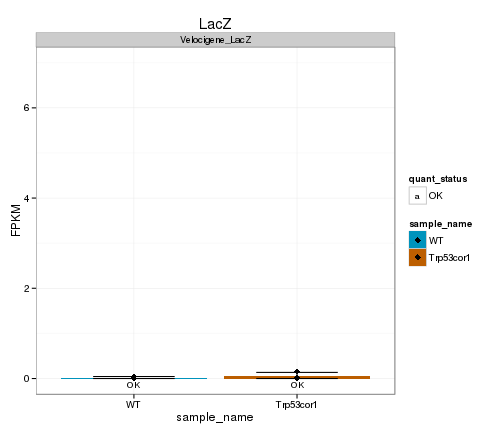

## Digital Genotyping (LacZ vs Endogenous lncRNA and Sex)

Eif2s3y is a y-expressed gene, Xist is an x-expressed gene Expression plot (endogenous linc, lacZ, Y-expressed gene):

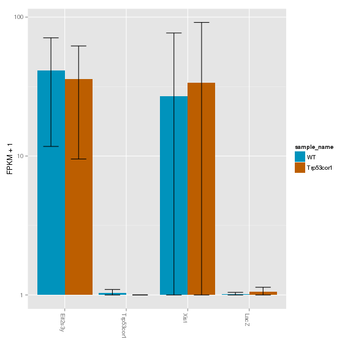

Expression heatmap:

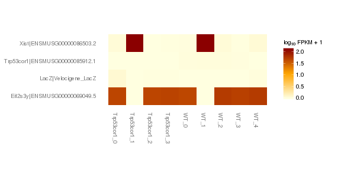

### Track visualization

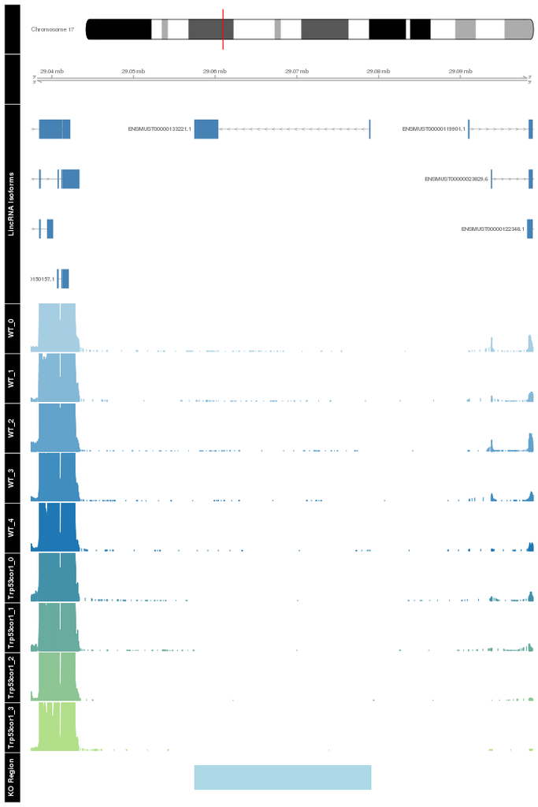

# Differential Analysis

## Differential Genes

There are 58 significantly differentially expressed genes. They are:

|  | geneAnnot$gene_short_name |
| --- | --- |
| 1 | Cnn1 |
| 2 | Ier3 |
| 3 | Cmah |
| 4 | Sulf1 |
| 5 | Myh11 |
| 6 | Arg1 |
| 7 | Adamdec1 |
| 8 | Slc15a2 |
| 9 | Cdkn1a |
| 10 | Cldn6 |
| 11 | Polh |
| 12 | Enpp4 |
| 13 | Tspo2 |
| 14 | Glo1 |
| 15 | E4f1 |
| 16 | Meiob |
| 17 | Ift140 |
| 18 | Clps |
| 19 | Igfbp5 |
| 20 | Cfh |
| 21 | Ifi202b |
| 22 | Hao1 |
| 23 | Stmn2 |
| 24 | Spp1 |
| 25 | Sparcl1 |
| 26 | Col1a2 |
| 27 | Ctrb1 |
| 28 | Akr1c14 |
| 29 | Cfhr2 |
| 30 | Hsd17b13 |
| 31 | Rnps1 |
| 32 | Acta2 |
| 33 | 3110052M02Rik |
| 34 | Azgp1 |
| 35 | Cyp3a16 |
| 36 | Igfbp2 |
| 37 | Myh6 |
| 38 | Pgm5 |
| 39 | Trem1 |
| 40 | Unc5cl |
| 41 | Epcam |
| 42 | Slitrk6 |
| 43 | Hmga1 |
| 44 | Gm4737 |
| 45 | H2-T24 |
| 46 | Krt15 |
| 47 | Cpa1 |
| 48 | Fxyd3 |
| 49 | Actg2 |
| 50 | Kng2 |
| 51 | Krt5 |
| 52 | Mocs1 |
| 53 | Zfp948 |
| 54 | Zfp213 |
| 55 | Cpa2 |
| 56 | Hmga1-rs1 |
| 57 | Rps2-ps10 |
| 58 | Gm9825 |

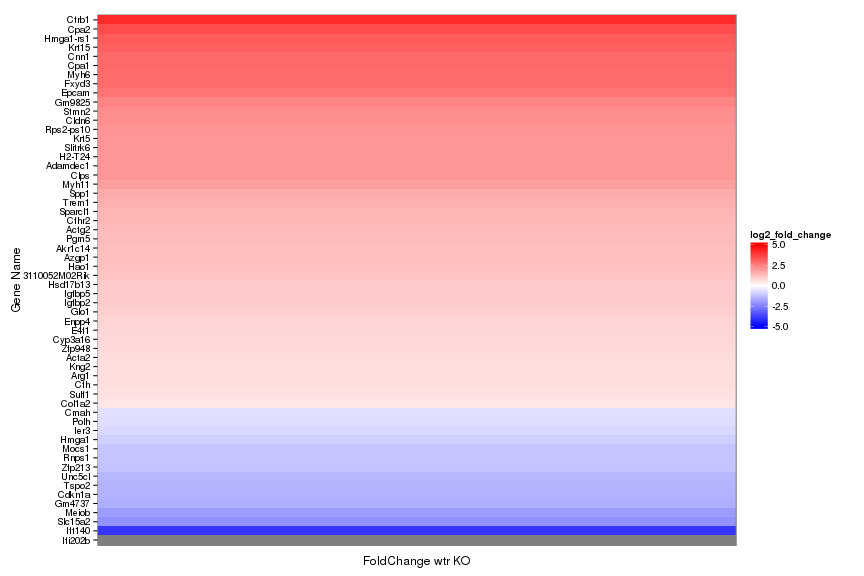

Expression heatmap of sigGenes

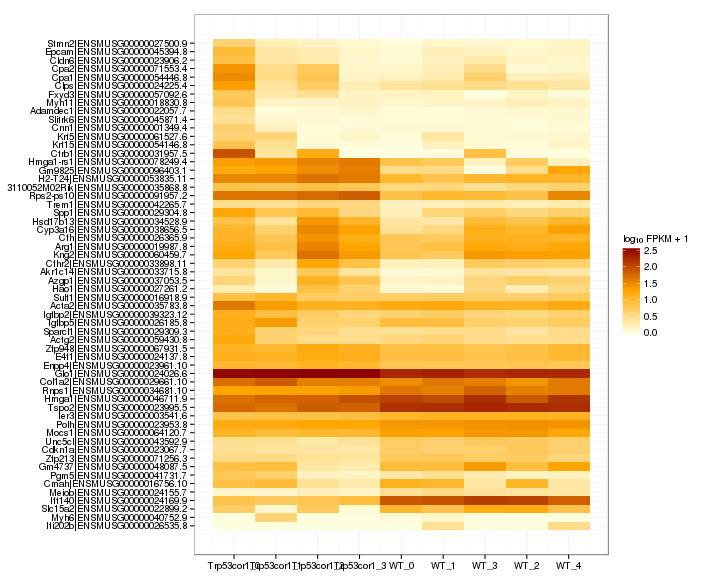

Foldchange heatmap of sigGenes

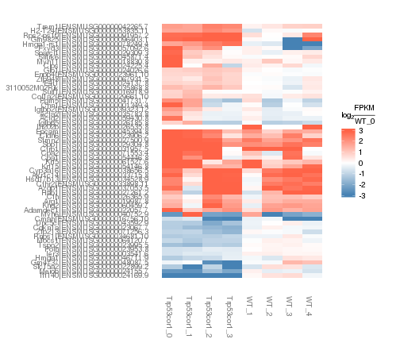

### Expression-level/significance relationship

Scatter plot of significant genes only:

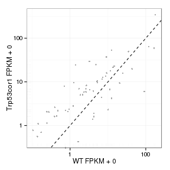

Volcano Plot

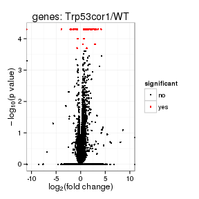

Volcano plot with significant genes only:

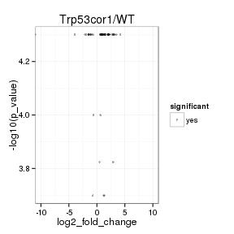

# Gene/Pathway Analysis

Enrichment and zscores are calculated based on expression in KO vs WT (fpkmKO/fpkmWT), so genes that are down regulated in KO are shown in blue, while upregulation is shown in red.

KO/WT Blue = down in KO Red = Up in KO

Biocarta enrichment:

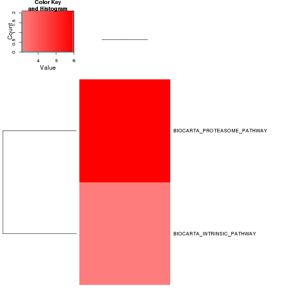

Biocarta zscore:

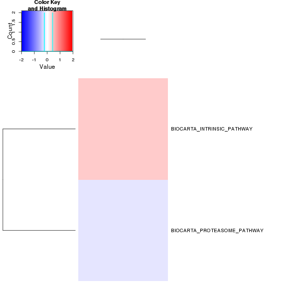

Reactome enrichment:

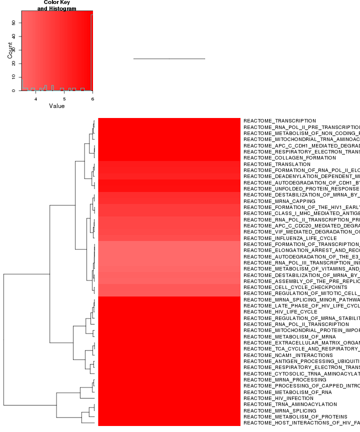

Reactome zscore:

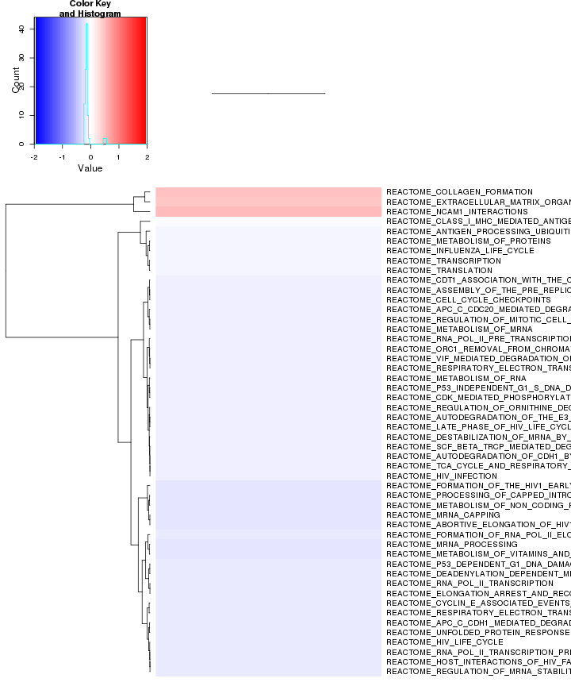

p53 enrichment:

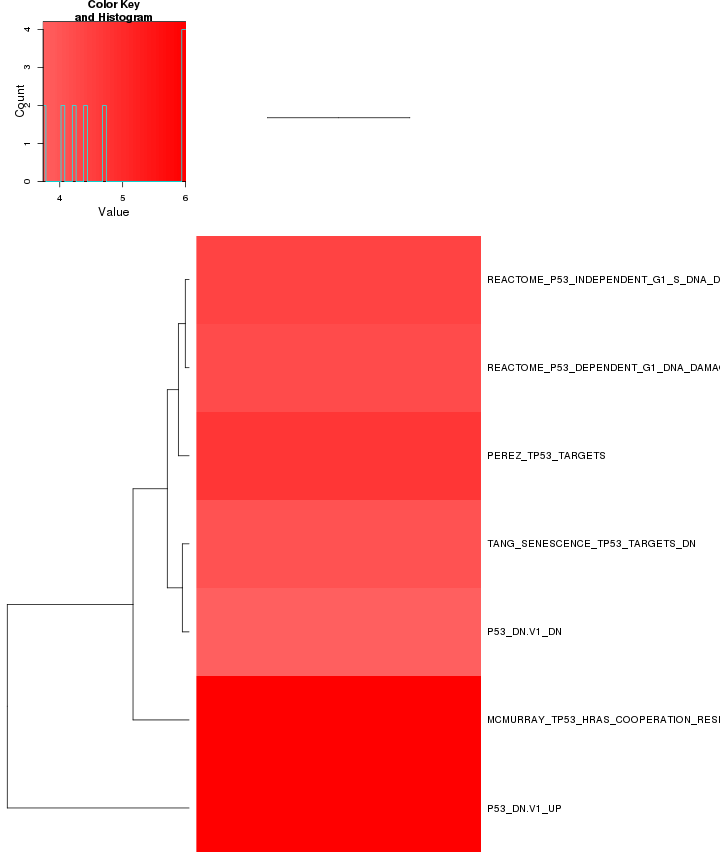

p53 zscore:

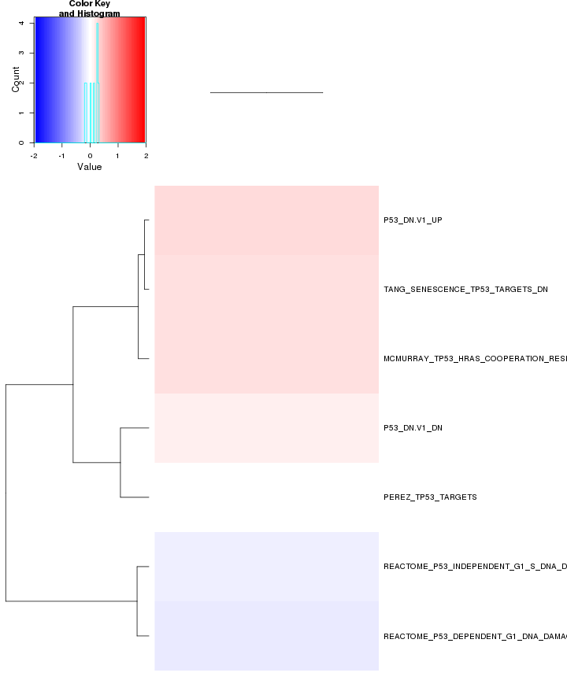

## GO enrichment

Cluster profiler used to call enichments of significantly differentially regulated genes that map to Entrez IDs.

[output not shown]

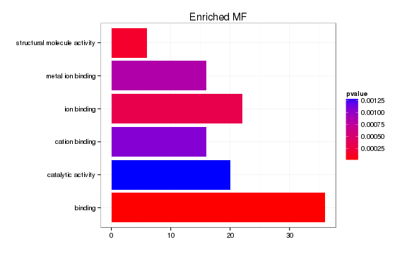

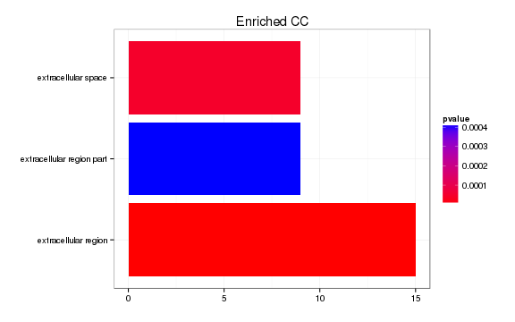

[output not shown]

[output not shown]

# Cis vs Trans (locally)

log2 Foldchange and test statistic are calculated with the ratio of fpkm(KO)/fpkm(WT), thus the test_stat is positive if a gene is higher in the KO and negative if a gene has lower expression in the KO

The pvalue for genes significantly regulated in a region this size is: 0.0099

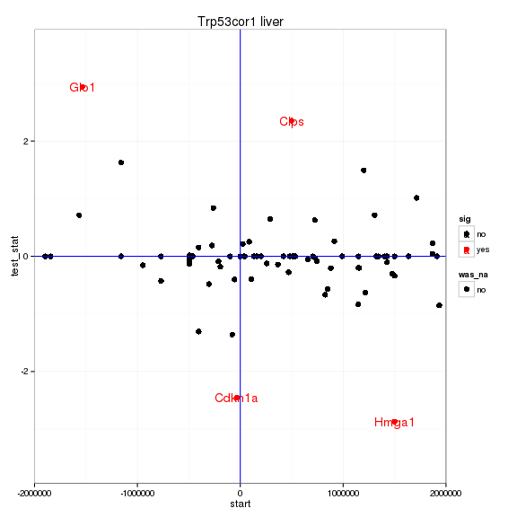

# Notes

## Samples used are:

|  | 11 |
| --- | --- |
| 1 | JR917 |
| 2 | JR933 |
| 3 | JR925 |
| 4 | lincp21_Liver_WT1 |
| 5 | lincp21_Liver_WT2 |
| 6 | JR926 |
| 7 | JR934 |
| 8 | lincp21_Liver_KO1 |
| 9 | lincp21_Liver_KO2 |

## Replicates

|  | file | sample_name | replicate | rep_name | total_mass | norm_mass | internal_scale | external_scale |
| --- | --- | --- | --- | --- | --- | --- | --- | --- |
| 1 | /n/rinn_data1/users/agroff/seq/OtherMice/Diana/lincP21/quants/JR917/abundances.cxb | WT | 0 | WT_0 | 37248000.00 | 26534800.00 | 1.48 | 1.00 |
| 2 | /n/rinn_data1/users/agroff/seq/OtherMice/Diana/lincP21/quants/JR933/abundances.cxb | WT | 1 | WT_1 | 34229100.00 | 26534800.00 | 1.32 | 1.00 |
| 3 | /n/rinn_data1/users/agroff/seq/OtherMice/Diana/lincP21/quants/JR925/abundances.cxb | WT | 2 | WT_2 | 40066200.00 | 26534800.00 | 1.52 | 1.00 |
| 4 | /n/rinn_data1/users/agroff/seq/OtherMice/Diana/lincP21/quants/lincp21_Liver_WT1/abundances.cxb | WT | 3 | WT_3 | 22564500.00 | 26534800.00 | 0.81 | 1.00 |
| 5 | /n/rinn_data1/users/agroff/seq/OtherMice/Diana/lincP21/quants/lincp21_Liver_WT2/abundances.cxb | WT | 4 | WT_4 | 17810700.00 | 26534800.00 | 0.65 | 1.00 |
| 6 | /n/rinn_data1/users/agroff/seq/OtherMice/Diana/lincP21/quants/JR926/abundances.cxb | Trp53cor1 | 0 | Trp53cor1_0 | 40299500.00 | 26534800.00 | 1.67 | 1.00 |
| 7 | /n/rinn_data1/users/agroff/seq/OtherMice/Diana/lincP21/quants/JR934/abundances.cxb | Trp53cor1 | 1 | Trp53cor1_1 | 30681900.00 | 26534800.00 | 1.24 | 1.00 |
| 8 | /n/rinn_data1/users/agroff/seq/OtherMice/Diana/lincP21/quants/lincp21_Liver_KO1/abundances.cxb | Trp53cor1 | 2 | Trp53cor1_2 | 15729200.00 | 26534800.00 | 0.54 | 1.00 |
| 9 | /n/rinn_data1/users/agroff/seq/OtherMice/Diana/lincP21/quants/lincp21_Liver_KO2/abundances.cxb | Trp53cor1 | 3 | Trp53cor1_3 | 16292900.00 | 26534800.00 | 0.58 | 1.00 |

## Run Info

[output not shown]